# NCEI Extreme Value Analysis

# 1 Goal

1. Access NCEI Daily GHCN Data
2. Explore Ways to Determine Return Periods for Extreme Events

A reference for the extRemes package can be found here

Gilleland, E., & Katz, R. (2016). extRemes 2.0: An Extreme Value Analysis Package in R. Journal of Statistical Software, 72(8), 1-39. doi:http://dx.doi.org/10.18637/jss.v072.i08 ( PDF Avaialble at https://www.jstatsoft.org/article/view/v072i08 )

# 2 Libraries

The following libraries are needed for this exercise.

Tidyverse Packages

- [tidyverse](https://www.tidyverse.org) : Set of commonly-used Data Science packages for R that it can install and load all at once. In the long-run you probably also want to install the tidyverse package suite anyway. For this exercise this will include…
  - [ggplot2](https://ggplot2.tidyverse.org) : Create Elegant Data Visualizations Using the Grammar of Graphics
  - [tibble](https://tibble.tidyverse.org) : Simple Data Frames
  - [tidyr](https://tidyr.tidyverse.org) : Tools for shepherding data in data frames.
  - [readr](https://readr.tidyverse.org) : Read Rectangular Text Data
  - [purr](https://purrr.tidyverse.org) : Functional Programming Tools
  - [dplyr](https://dplyr.tidyverse.org) : A grammar of data manipulation
  - [stringr](https://stringr.tidyverse.org) : Simple, Consistent Wrappers for Common String Operations
  - [forcats](https://forcats.tidyverse.org) : Tools for Working with Categorical Variables (Factors)
- [lubridate](https://lubridate.tidyverse.org) : Time and Date Management

Other Packages

```r
# Libraries

  # Tidyverse resources

  library(package = "tidyverse") # Multiple Tidyverse Resources
  library(package = "lubridate") # Date-Time Control
  library(package = "ggridges")  # Ridgeline plots with ggplot2
  # NOAA Libraries

  library(package = "rnoaa") # NCEI  Data Retrieval Package
  # NCAR Libraries

  library(package = "extRemes") # NCEI  Data Retrieval Package
```

# 3 Extracting Data

## 3.1. Case and Inventory

For this we are going to extract daily Global Historical Climate Network data from Rapid City Airport (the GHCN station ID for the airport is… **GHCND:USW00024090**) and can be found searching at this website:

https://www.ncdc.noaa.gov/cdo-web/search

We can get the details for the station using the option “stationid = ‘GHCND:USW00024090’”

```r
# Extracting Data

  # Station Details for Rapid City Airport , SD

  stationid_for_ncdcstations = 'GHCND:USW00024090'

  stationid_for_ghcn_pull    = 'USW00024090'

  ncdc_ids = ncdc_stations(stationid = stationid_for_ncdcstations)

  ncdc_ids = ncdc_ids$data
```

Also to get an inventory of the avaialble data for this station we can use the [ncdc_datatypes()](https://www.rdocumentation.org/packages/rnoaa/versions/0.8.4/topics/ncdc_datatypes) command.

```r
  # Get Available Parameters for a given station from a specific dataset

  ncdc_datatypes(datasetid = 'GHCND',
                 stationid = stationid_for_ncdcstations)$data
```

| mindate | maxdate | name | datacoverage | id |
| --- | --- | --- | --- | --- |
| 1965-01-01 | 2005-12-31 | Average cloudiness midnight to midnight from manual observations | 1 | ACMH |
| 1965-01-01 | 2005-12-31 | Average cloudiness sunrise to sunset from manual observations | 1 | ACSH |
| 1982-01-01 | 2019-06-22 | Average wind speed | 1 | AWND |
| 1982-01-01 | 2013-03-31 | Time of fastest mile or fastest 1-minute wind | 1 | FMTM |
| 1948-01-01 | 2019-06-22 | Peak gust time | 1 | PGTM |
| 1781-01-01 | 2019-06-23 | Precipitation | 1 | PRCP |
| 1965-01-01 | 2019-06-21 | Daily percent of possible sunshine for the period | 1 | PSUN |
| 1840-05-01 | 2019-06-23 | Snowfall | 1 | SNOW |
| 1857-01-18 | 2019-06-23 | Snow depth | 1 | SNWD |
| 1874-10-13 | 2019-06-23 | Average Temperature. | 1 | TAVG |

[output cut: 15 more lines]

```r
NA
```

## 3.2 Pulling the Raw Data from NCDC/NCEI

To pull the daily GHCN data for this station we use the [ghcnd()](https://www.rdocumentation.org/packages/rnoaa/versions/0.8.4/topics/ghcnd) function. We should be just able to ask, again, for the station ID for the airport.

```r
# Pull the Raw Climate Data from a Single Station

ghcn_data = ghcnd(stationid = stationid_for_ghcn_pull)
```

```
file path:          /Users/wjc/Library/Caches/rnoaa/ghcnd/USW00024090.dly
file last updated:  2019-06-24 11:53:11
```

```r
ghcn_data
```

| id | year | month | element | VALUE1 | MFLAG1 | QFLAG1 | SFLAG1 | VALUE2 | MFLAG2 | QFLAG2 | SFLAG2 | VALUE3 | MFLAG3 | QFLAG3 | SFLAG3 | VALUE4 | MFLAG4 | QFLAG4 | SFLAG4 | VALUE5 | MFLAG5 | QFLAG5 | SFLAG5 | VALUE6 | MFLAG6 | QFLAG6 | SFLAG6 | VALUE7 | MFLAG7 | … |
| --- | --- | --- | --- | --- | --- | --- | --- | --- | --- | --- | --- | --- | --- | --- | --- | --- | --- | --- | --- | --- | --- | --- | --- | --- | --- | --- | --- | --- | --- | --- |
| USW00024090 | 1948 | 5 | TMAX | 117 |  |  | 0 | 139 |  |  | 0 | 156 |  |  | 0 | 178 |  |  | 0 | 117 |  |  | 0 | 194 |  |  | 0 | 211 |  | … |
| USW00024090 | 1948 | 5 | TMIN | 44 |  |  | 0 | 11 |  |  | 0 | 6 |  |  | 0 | 22 |  |  | 0 | 11 |  |  | 0 | 6 |  |  | 0 | 44 |  | … |
| USW00024090 | 1948 | 5 | PRCP | 76 |  |  | 0 | 0 | T |  | 0 | 0 |  |  | 0 | 0 | T |  | 0 | 3 |  |  | 0 | 0 |  |  | 0 | 0 | T | … |
| USW00024090 | 1948 | 5 | SNOW | 0 |  |  | 0 | 0 |  |  | 0 | 0 |  |  | 0 | 0 |  |  | 0 | 0 |  |  | 0 | 0 |  |  | 0 | 0 |  | … |
| USW00024090 | 1948 | 5 | SNWD | 0 |  |  | 0 | 0 |  |  | 0 | 0 |  |  | 0 | 0 |  |  | 0 | 0 |  |  | 0 | 0 |  |  | 0 | 0 |  | … |
| USW00024090 | 1948 | 5 | WT01 | NA |  |  |  | NA |  |  |  | NA |  |  |  | NA |  |  |  | NA |  |  |  | NA |  |  |  | NA |  | … |
| USW00024090 | 1948 | 5 | WT03 | NA |  |  |  | NA |  |  |  | NA |  |  |  | NA |  |  |  | NA |  |  |  | NA |  |  |  | NA |  | … |
| USW00024090 | 1948 | 5 | WT14 | NA |  |  |  | NA |  |  |  | NA |  |  |  | NA |  |  |  | NA |  |  |  | NA |  |  |  | NA |  | … |
| USW00024090 | 1948 | 6 | TMAX | 289 |  |  | 0 | 300 |  |  | 0 | 256 |  |  | 0 | 256 |  |  | 0 | 239 |  |  | 0 | 261 |  |  | 0 | 294 |  | … |
| USW00024090 | 1948 | 6 | TMIN | 133 |  |  | 0 | 167 |  |  | 0 | 156 |  |  | 0 | 111 |  |  | 0 | 144 |  |  | 0 | 128 |  |  | 0 | 128 |  | … |

[output cut: 990 more lines]

```r
NA
```

## 3.3 Making the Messy Raw Data from NCDC/NCEI look pretty

As you can see this format isn’t all that pretty. Data from NCEI/NCDC is archived by so one line of data is the whole 31-, 30-, 28- or 29-day month so all of the month is on one line.

Luckily there is a function that pulls this out called ghcnd_splitvars

It will split the output of the ghcn() data into multiple data frames

```r
  # reshape the ghcn daily data input fields

  ghcn_data = ghcnd_splitvars(x = ghcn_data)

  # print(ghcn_data) # (this is messy it makes as many data "sub"-frames as you have variables
                     #  you can uncomment
```

The downside in the above output is that there are no units mentioned here. But they *are* available on the original data website here:

https://www1.ncdc.noaa.gov/pub/data/ghcn/daily/readme.txt

From the dataset the five basic parameters are

| Code | Parameter Name | Units |
| --- | --- | --- |
| PRCP | Precipitation wrt 0000-0000 Local Time | ⅒ of mm |
| SNOW | Snowfall wrt 0000-0000 Local Time | mm |
| SNWD | Snow depth wrt 0000-0000 Local Time | mm |
| TMAX | Maximum temperature wrt 0000-0000 Local Time | ⅒ of °C |
| TMIN | Minimum temperature wrt 0000-0000 Local Time | ⅒ of °C |

And you may have

| Code | Parameter Name | Units |
| --- | --- | --- |
| TAVG | Average temperature wrt 0000-0000 UTC | ⅒ of °C |

These really are the only parameters I normally pull.

I’m doing this by brute force and changing the temperature units to °F while I am at it…

```r
  # Changing Units

  ghcn_data$tmax$tmax = ghcn_data$tmax$tmax / 10.0
  ghcn_data$tmin$tmin = ghcn_data$tmin$tmin / 10.0
  ghcn_data$tavg$tavg = ghcn_data$tavg$tavg / 10.0
  ghcn_data$prcp$prcp = ghcn_data$prcp$prcp / 10.0


  ghcn_data$tmax$tmax = ghcn_data$tmax$tmax * 9. / 5. + 32
  ghcn_data$tmin$tmin = ghcn_data$tmin$tmin * 9. / 5. + 32
  ghcn_data$tavg$tavg = ghcn_data$tavg$tavg * 9. / 5. + 32
```

## 3.4 Creating a Working Data Table

```r
  daily_gcnd_frame = left_join(ghcn_data$tmin,
                               ghcn_data$tmax,
                               by = c("id", "date"))


  daily_gcnd_frame = left_join(daily_gcnd_frame,
                               ghcn_data$prcp,
                               by=c("id", "date"))

  daily_gcnd_frame = left_join(daily_gcnd_frame,
                               ghcn_data$snow,
                               by=c("id", "date"))

  daily_gcnd_frame = left_join(daily_gcnd_frame,
                               ghcn_data$snwd,
                               by=c("id", "date"))

  ghcn_data = daily_gcnd_frame

  remove(daily_gcnd_frame) # tidy as you go
```

We also have to drop the three quality flag variables and neatly reorder and drop lines with all missing data. …

```r
  ghcn_data = ghcn_data %>%
    select(c(id,
             date,
             tmin,
             tmax,
             prcp,
             snow,
             snwd)) %>%
    filter(!(is.na(tmin) &
             is.na(tmax) &
             is.na(prcp) &
             is.na(snow) &
             is.na(prcp) &
             is.na(snow) &
             is.na(snwd))) %>%
    arrange(date)
```

And with that we can now [finally] play!

# 4 Managing the Data…

We need to make sure that we have a continious data record.

First let’s trim the front and end of the record to remove partial years at the beginning and end of the record.

```r
# Getting first complete year of record.

  min_date = min(ghcn_data$date)

  if ((month(min_date) != 1) |
      (day(min_date)   != 1) )
    {
      ghcn_data = ghcn_data %>%
        filter(year(date) >= ((year(min_date)+1)))
    }

# Getting last complete year of record.

  max_date = max(ghcn_data$date)

  if ( (month(max_date) != 12) &
       (day(max_date)   != 31) )
    {
      ghcn_data = ghcn_data %>%
        filter(year(date) <= ((year(max_date)-1)))
  }

# Insert Any Fully Missing Days

  min_date = min(ghcn_data$date)
  max_date = max(ghcn_data$date)

  temp_frame = tibble(date = seq(from = min_date,
                                 to   = max_date,
                                 by   = "1 day"))

  ghcn_data = right_join(x  = ghcn_data,
                         y  = temp_frame,
                         by = "date")



 # List Missing Days (*we're only checking precip data here*)

  ghcn_data %>% filter(is.na(ghcn_data$prcp))
```

| id | date | tmin | tmax | prcp | snow | snwd |
| --- | --- | --- | --- | --- | --- | --- |
| NA | 1996-10-26 | NA | NA | NA | NA | NA |
| NA | 1996-10-27 | NA | NA | NA | NA | NA |
| NA | 1996-10-28 | NA | NA | NA | NA | NA |
| USW00024090 | 1996-12-21 | -0.94 | 28.94 | NA | NA | NA |
| USW00024090 | 1996-12-22 | -5.98 | -0.94 | NA | NA | NA |
| USW00024090 | 2002-02-10 | 6.08 | 44.96 | NA | NA | NA |

```r
  proportionMissing = sum(is.na(ghcn_data$prcp)) / sum(!is.na(ghcn_data$prcp))

  str_c("Proportion Missing (missing:available) = ",
        proportionMissing)
```

```
[1] "Proportion Missing (missing:available) = 0.000234732600445992"
```

If and ONLY if you feel that you can fill any missing data with climatological or zero values you can do so but you should document(as above) the missing dates.

For “safety” I am creating a new variable where those values are replaced by zero.

```r
# fill the SMALL number of missing days with zeros and whistle in the dark


whistle_in_the_dark = TRUE

if (whistle_in_the_dark)
  {
    ghcn_data_unmissing = ghcn_data %>%
                              mutate(prcp = replace(x      = prcp,
                                                    list   = is.na(prcp),
                                                    values = 0))
  }
```

Let’s make a histogram of the data we have.

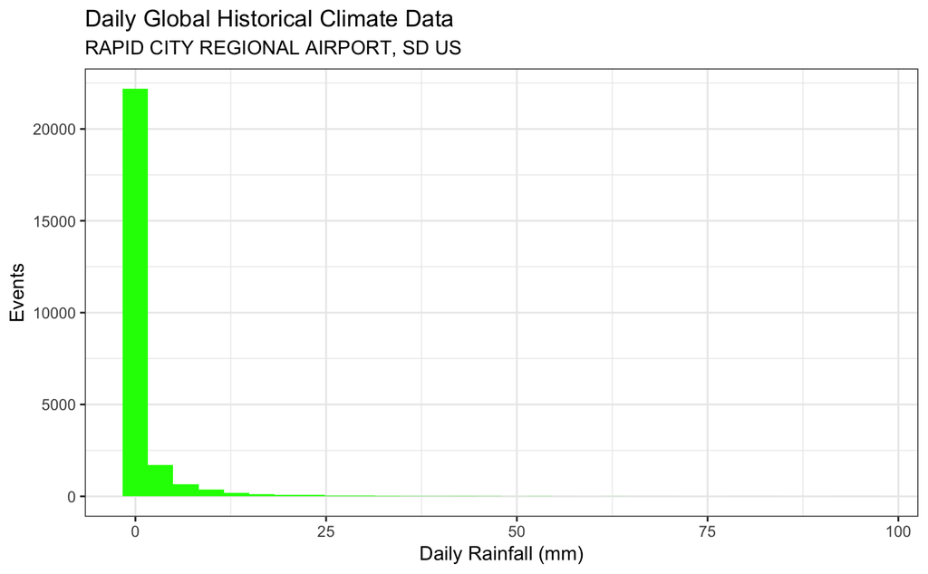

```r
ggplot(data = ghcn_data) +   # use ghcn_data as the source of the data

  aes(x = prcp) +

  theme_bw() +              # use a very simple ploting theme

  ggtitle(label    = "Daily Global Historical Climate Data",
          subtitle = ncdc_ids$name) +

  ylab(label = "Events") +

  xlab(label = "Daily Rainfall (mm)") +

  geom_histogram(fill = "green")  # make a simple line plot (and make it pink)
```

```r
NA
NA
```

Obviously we can guess that most of those days are either no rain or a trace of rain. We can remove those and try again.

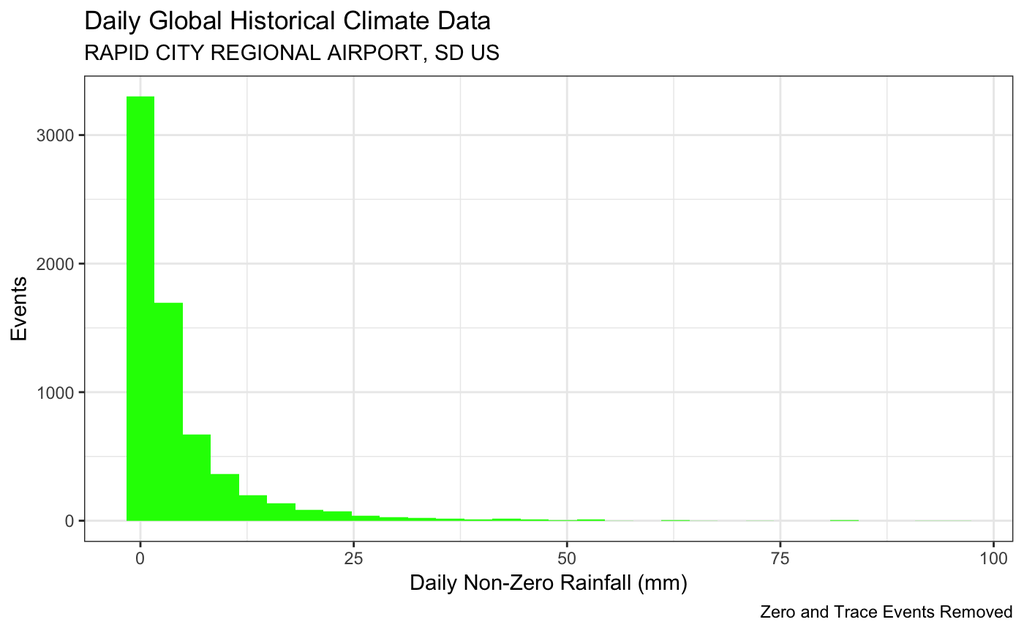

```r
ggplot(data = ghcn_data %>% filter(prcp > 0)) +   # tidy out

  aes(x = prcp) +

  theme_bw() +              # use a very simple ploting theme

  ggtitle(label    = "Daily Global Historical Climate Data",
          subtitle = ncdc_ids$name) +

  labs(caption = "Zero and Trace Events Removed") +

  ylab(label = "Events") +

  xlab(label = "Daily Non-Zero Rainfall (mm)") +

  geom_histogram(fill = "green")  # make a simple line plot (and make it pink)
```

```r
NA
NA
```

Likewise we can identify an extreme event thesholds as those only being in the top 5% of daily rainfall events

```r
# Establish a 95% non-zero rain threshold (a reasonable S.W.A.G.)

subset = ghcn_data %>% filter(prcp > 0)
threshold = quantile(x     = subset$prcp,
                     probs = 0.95)

remove(subset) # "tidy as you go"

str_c("75% Daily Non-Zero Rain Threshold is ",
      threshold,
      " mm")
```

[output not shown]

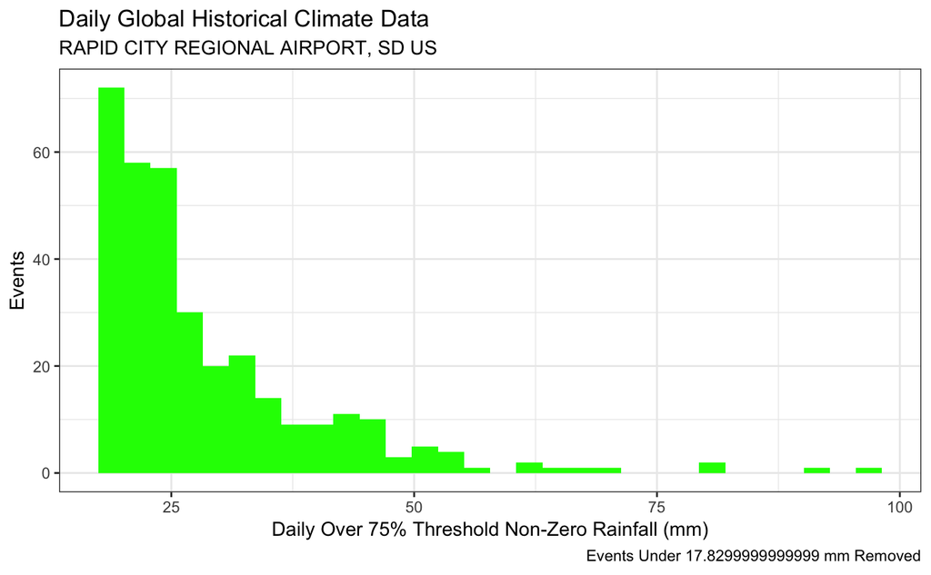

```r
ggplot(data = ghcn_data %>% filter(prcp > threshold)) +   # tidy out

  aes(x = prcp) +

  theme_bw() +              # use a very simple ploting theme

  ggtitle(label    = "Daily Global Historical Climate Data",
          subtitle = ncdc_ids$name) +

  labs(caption = str_c("Events Under ", threshold," mm Removed")) +

  ylab(label = "Events") +

  xlab(label = "Daily Over 75% Threshold Non-Zero Rainfall (mm)") +

  geom_histogram(fill = "green")  # make a simple line plot (and make it pink)
```

```r
NA
NA
```

# 5 Time to Explore Some Extreme Events

## 5.1 Classic Method for Returns Intervals

The “old school” way to do this is as follows

```r
  # calculations precipitation ranking


  precip_by_year = ghcn_data %>%
    group_by(year = year(date)) %>%
    summarise(max_daily_prcp = max(x     = prcp,
                                   na.rm = TRUE))
  nYears = nrow(x       = precip_by_year)

  # rank values from high to low

  prcp_ranked_by_year = precip_by_year %>%
    arrange(desc(max_daily_prcp))

  # rank values from high to low

  prcp_ranked_by_year = prcp_ranked_by_year %>%
    mutate(rank            = rank(desc(max_daily_prcp)))

  # get return intervals

  prcp_ranked_by_year = prcp_ranked_by_year %>%
    mutate(return_interval = (nYears - 1) / rank)

  # get probability of occurance per year

  prcp_ranked_by_year <- prcp_ranked_by_year %>%
    mutate(prob_of_event = ((1/return_interval)))


  # display table

  prcp_ranked_by_year
```

| year | max_daily_prcp | rank | return_interval | prob_of_event |
| --- | --- | --- | --- | --- |
| 1963 | 96.0 | 1.0 | 69.0000000 | 0.01449275 |
| 1976 | 91.4 | 2.0 | 34.5000000 | 0.02898551 |
| 1965 | 81.5 | 3.0 | 23.0000000 | 0.04347826 |
| 1997 | 81.0 | 4.0 | 17.2500000 | 0.05797101 |
| 1999 | 71.1 | 5.0 | 13.8000000 | 0.07246377 |
| 1982 | 66.0 | 6.0 | 11.5000000 | 0.08695652 |
| 1980 | 63.8 | 7.0 | 9.8571429 | 0.10144928 |
| 2015 | 62.5 | 8.0 | 8.6250000 | 0.11594203 |
| 1986 | 55.4 | 9.0 | 7.6666667 | 0.13043478 |
| 1966 | 54.1 | 10.0 | 6.9000000 | 0.14492754 |

[output cut: 60 more lines]

```r
NA
```

Let’s also take a peak at the histogram when aggregated to years rather than daily.

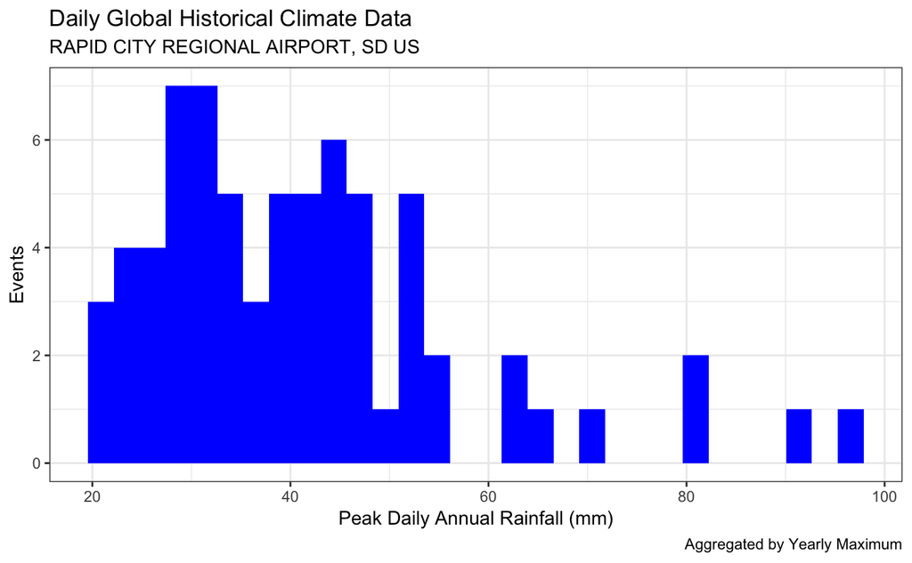

```r
ggplot(data = precip_by_year) +   # tidy out

  aes(x = max_daily_prcp) +

  theme_bw() +              # use a very simple ploting theme

  ggtitle(label    = "Daily Global Historical Climate Data",
          subtitle = ncdc_ids$name) +

  labs(caption = "Aggregated by Yearly Maximum") +

  ylab(label = "Events") +

  xlab(label = "Peak Daily Annual Rainfall (mm)") +

  geom_histogram(fill = "blue")  # make a simple line plot (and make it pink)
```

```r
NA
NA
```

We can also make this fancier and make a smoothed distribution of our histrogram (this’ll be important later)

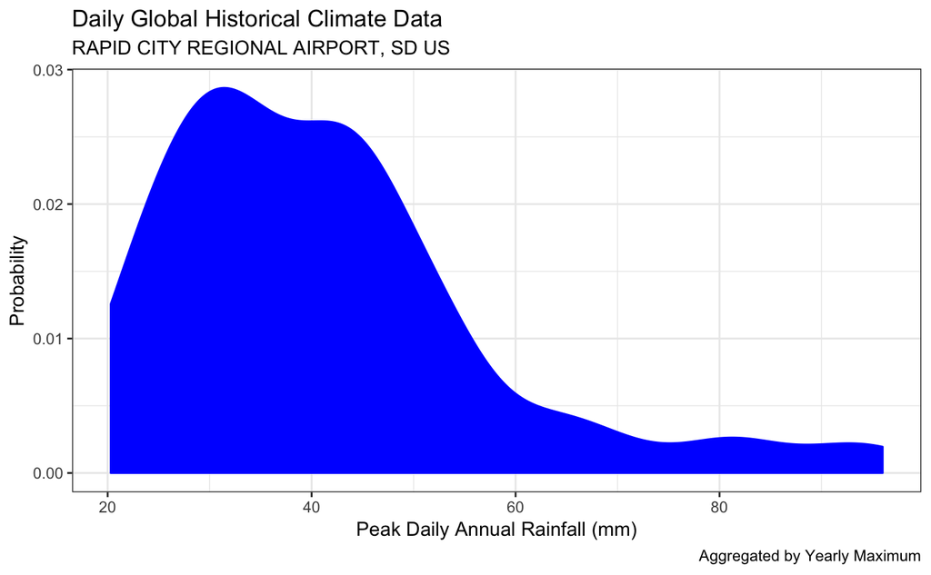

```r
ggplot(data = precip_by_year) +   # tidy out

  aes(x = max_daily_prcp) +

  theme_bw() +              # use a very simple ploting theme

  ggtitle(label    = "Daily Global Historical Climate Data",
          subtitle = ncdc_ids$name) +

  labs(caption = "Aggregated by Yearly Maximum") +

  ylab(label = "Probability") +

  xlab(label = "Peak Daily Annual Rainfall (mm)") +

  geom_density(fill = "blue",
               color = "blue",
               trim  = FALSE)
```

```r
NA
NA
```

Let’s plot the frequency of returns by the observed precipitation period.

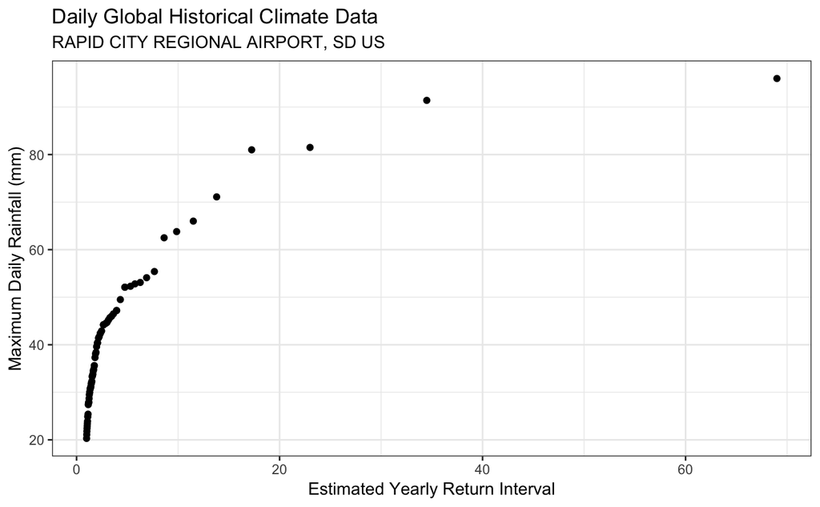

```r
#  plot rainfal vs return period.

ggplot(data = prcp_ranked_by_year) +

  aes(x =  return_interval,
      y = max_daily_prcp)  +

  theme_bw() +

  ggtitle(label    = "Daily Global Historical Climate Data",
          subtitle = ncdc_ids$name) +

  xlab(label = "Estimated Yearly Return Interval")  +

  ylab(label = "Maximum Daily Rainfall (mm)")  +


  geom_point()
```

Like many return periods these data resmble a log plot so that *prec* = *f*( ln(*RP*))

We can fit a curve to this to see if we can get a reasonable relationship.

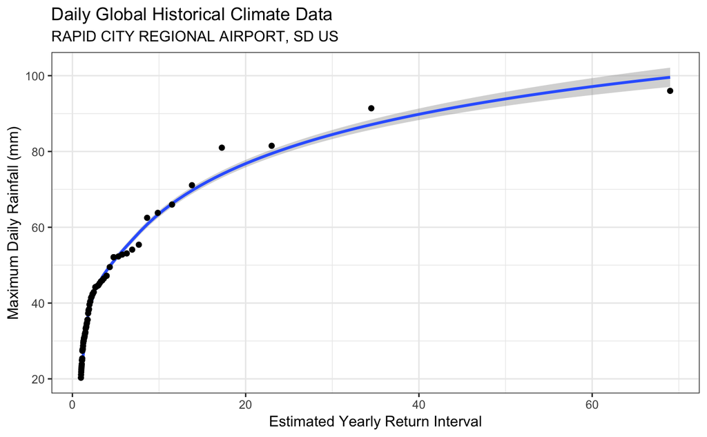

```r
#  plot rainfal vs return period -- with curve fit

ggplot(data = prcp_ranked_by_year) +

  aes(x = return_interval,
      y = max_daily_prcp)  +

  theme_bw() +

  ggtitle(label    = "Daily Global Historical Climate Data",
          subtitle = ncdc_ids$name) +

  xlab(label = "Estimated Yearly Return Interval")  +

  ylab(label = "Maximum Daily Rainfall (mm)")  +

  stat_smooth(formula = y ~ log(x),
              na.rm   = TRUE) +

  geom_point()
```

```r
NA
NA
NA
```

We also can extrapolate to longer events.

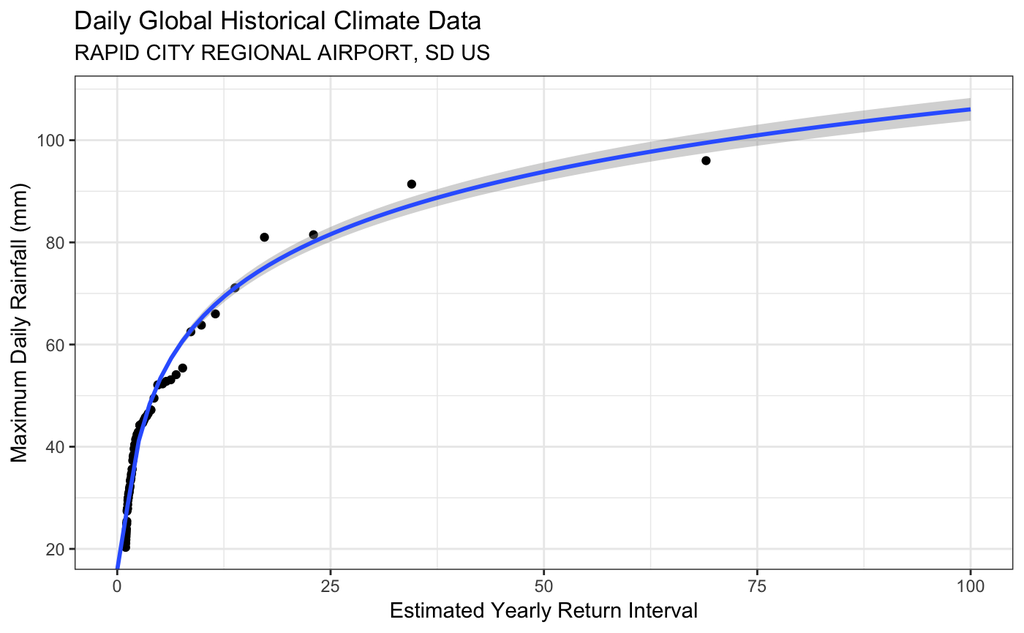

```r
#  plot rainfal vs return period -- with curve fit -- extended

ggplot(data = prcp_ranked_by_year) +

  aes(x = return_interval,
      y = max_daily_prcp)  +

  theme_bw() +

  ggtitle(label    = "Daily Global Historical Climate Data",
          subtitle = ncdc_ids$name) +

  xlab(label = "Estimated Yearly Return Interval")  +

  ylab(label = "Maximum Daily Rainfall (mm)")  +



  xlim(0, 100) +

  geom_point() +

  stat_smooth(formula   = y ~ log(x),
              method    = "lm",
              fullrange = TRUE)
```

```r
NA
NA
```

To get the actual values we can run the function that sits inside the geom_smooth function, lm

```r
# getting coefficients for the linear model

lmFit_yearly_return_period_vs_precp = lm(formula =max_daily_prcp ~ log(return_interval),
                                         data = prcp_ranked_by_year)

summary(lmFit_yearly_return_period_vs_precp)
```

```
Call:
lm(formula = max_daily_prcp ~ log(return_interval), data = prcp_ranked_by_year)

Residuals:
   Min     1Q Median     3Q    Max
-5.342 -1.643  0.340  1.030  5.955

Coefficients:
                     Estimate Std. Error t value Pr(>|t|)
(Intercept)           24.8157     0.3843   64.57   <2e-16 ***
log(return_interval)  17.6377     0.2945   59.90   <2e-16 ***
---
Signif. codes:  0 ‘***’ 0.001 ‘**’ 0.01 ‘*’ 0.05 ‘.’ 0.1 ‘ ’ 1

Residual standard error: 2.225 on 68 degrees of freedom
Multiple R-squared:  0.9814,    Adjusted R-squared:  0.9811
F-statistic:  3588 on 1 and 68 DF,  p-value: < 2.2e-16
```

likewise, we can apply the model to any external data with the predict function

```r
# applying the model to select values

test_return_periods = tibble(return_interval = c(5, 10, 50, 100, 500))

test_return_periods$precip_predicted = predict.lm(object  = lmFit_yearly_return_period_vs_precp,
                                                  newdata = test_return_periods)

test_return_periods
```

| return_interval | precip_predicted |
| --- | --- |
| 5 | 53.20252 |
| 10 | 65.42805 |
| 50 | 93.81486 |
| 100 | 106.04040 |
| 500 | 134.42721 |

## 5.2 The fancy newfangled way to do this.

Along with the classic method there are methods based on probability distributions.

The [NCAR ExtRemes Package](https://ral.ucar.edu/staff/ericg/extRemes/)

```r
fit_GEV_yearly  = fevd(x          = precip_by_year$max_daily_prcp, #
                      verbose    = TRUE,
                      units      = "mm",
                      time.units = "year",
                      type       = "GEV"
                      )
```

```
Setting up parameter model design matrices.
Parameter model design matrices set up.
Using Lmoments estimates as initial estimates.  Initial value = 281.8787
Initial estimates are:
  location      scale      shape
33.7161710 11.0815310  0.1081807
Beginning estimation procedure.
Time difference of 0.05815721 secs
```

```r
summary(fit_GEV_yearly)
```

```
fevd(x = precip_by_year$max_daily_prcp, type = "GEV", units = "mm",
    time.units = "year", verbose = TRUE)

[1] "Estimation Method used: MLE"


 Negative Log-Likelihood Value:  281.7202


 Estimated parameters:
  location      scale      shape
33.5833023 10.5840840  0.1503586

 Standard Error Estimates:
 location     scale     shape
1.4707961 1.1507360 0.1106641

 Estimated parameter covariance matrix.
            location       scale       shape
location  2.16324128  0.93872844 -0.06227891
scale     0.93872844  1.32419325 -0.02967912
shape    -0.06227891 -0.02967912  0.01224655

 AIC = 569.4404

 BIC = 576.1859
```

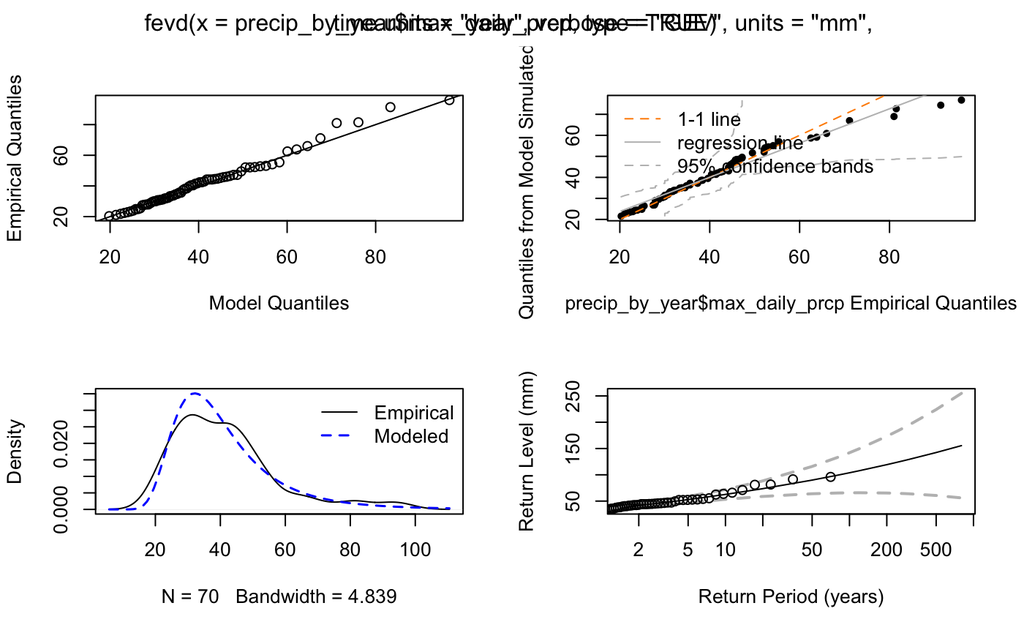

```r
plot(fit_GEV_yearly)
```

That’s not all that pretty but we can focus for now on the lower right which is basically the same plot classic method by requesting the “return level”

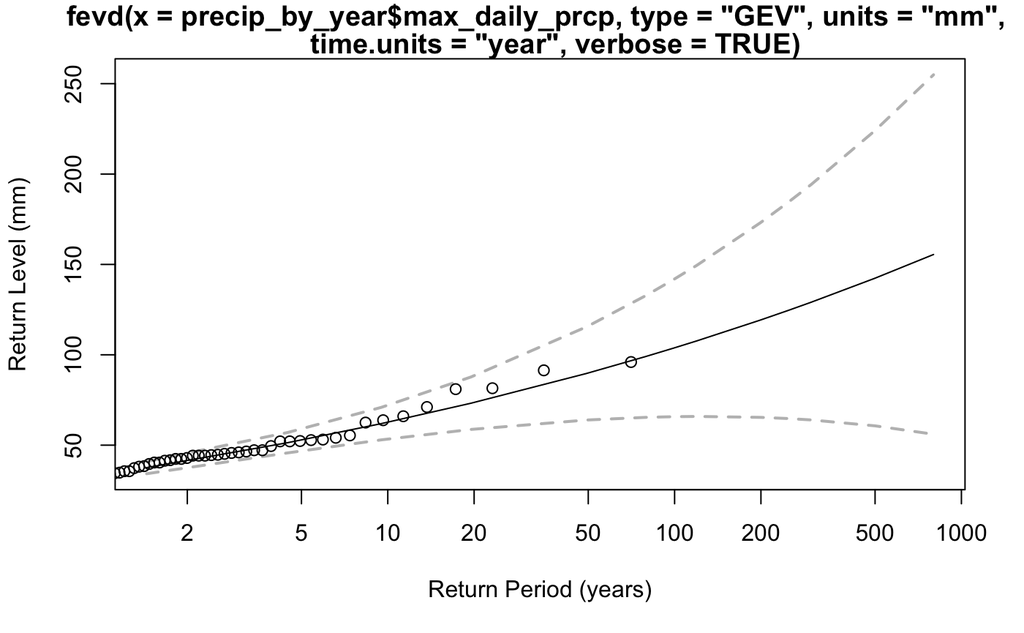

```r
# plot just the return periods.  We'll make it prettier later.

plot(fit_GEV_yearly, type = c("rl"))
```

```r
NA
NA
```

You can also do this with daily values but you will need to use that 95% daily percentile value as a threshold. You;ll need to have no missing data here so we’ll use the whistle-in-the-dark version.

```r
fit_GP_daily   = fevd(x          = ghcn_data_unmissing$prcp, #
                      verbose    = TRUE,
                      units      = "mm",
                      threshold  = threshold,
                      time.units = "365.25/year",
                      type       = "GP")
```

```
 Data span  69.99589 years
Setting up parameter model design matrices.
Parameter model design matrices set up.
Using Lmoments estimates as initial estimates.  Initial value = 1126.912
Initial estimates are:
    scale     shape
9.5183367 0.1177627
Beginning estimation procedure.
Time difference of 0.117537 secs
```

```r
summary(fit_GP_daily)
```

```
fevd(x = ghcn_data_unmissing$prcp, threshold = threshold, type = "GP",
    units = "mm", time.units = "365.25/year", verbose = TRUE)

[1] "Estimation Method used: MLE"


 Negative Log-Likelihood Value:  1126.873


 Estimated parameters:
    scale     shape
9.7133896 0.1003525

 Standard Error Estimates:
     scale      shape
0.81188314 0.06342114

 Estimated parameter covariance matrix.
            scale        shape
scale  0.65915423 -0.035859510
shape -0.03585951  0.004022241

 AIC = 2257.745

 BIC = 2265.367
```

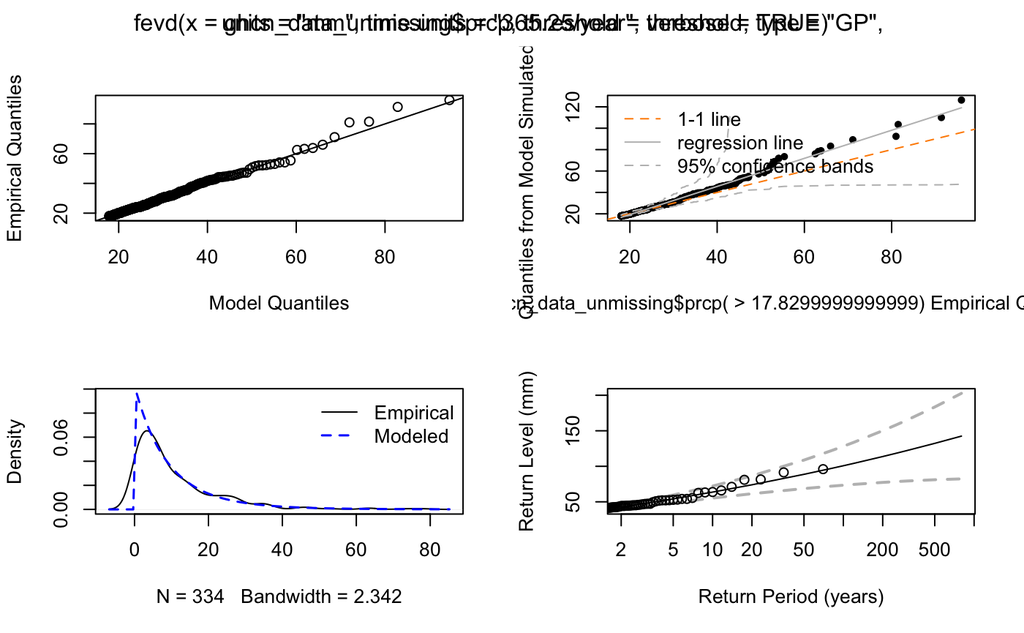

```r
plot(fit_GP_daily)
```

and again to blow things up on that last plot…

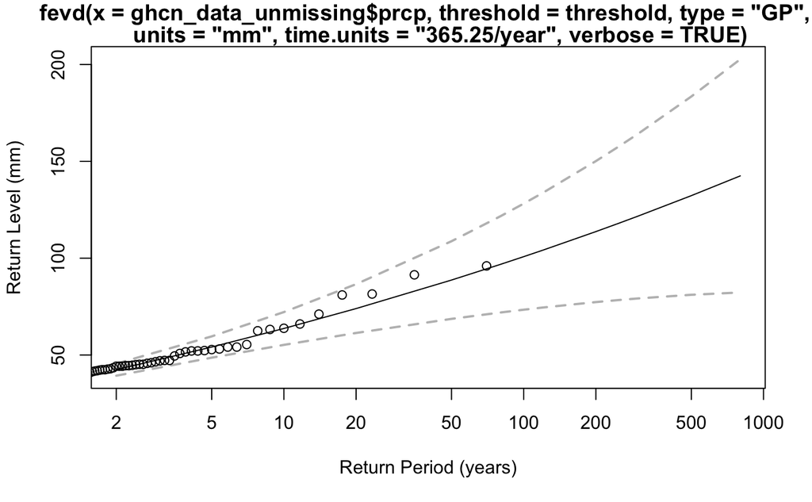

```r
# plot just the return periods.  We'll make it prettier later.

plot(fit_GP_daily, type = c("rl"))
```

# 6 Comparing these methods

We can use a the return.level

It works like the previous predict() function

```r
fitted_return_periods_GP_daily       = tibble(return_interval = 2:100)
fitted_return_periods_GEV_yearly     = tibble(return_interval = 2:100)
fitted_return_periods_classic_yearly = tibble(return_interval = 2:100)

fitted_return_periods_GP_daily$method       = "GP Daily"
fitted_return_periods_GEV_yearly$method     = "GEV Yearly"
fitted_return_periods_classic_yearly$method = "Classic"

fitted_return_periods_GP_daily$max_daily_prcp  =
            return.level(x             = fit_GP_daily,
                         return.period = fitted_return_periods_GP_daily$return_interval)

fitted_return_periods_GEV_yearly$max_daily_prcp  =
            return.level(x             = fit_GEV_yearly,
                         return.period = fitted_return_periods_GEV_yearly$return_interval)

fitted_return_periods_classic_yearly$max_daily_prcp  =
            predict.lm(object  = lmFit_yearly_return_period_vs_precp,
                       newdata = fitted_return_periods_classic_yearly)
```

Let’s collect these into a single data frame…

```r
# concatenate (slap together) all the data frames

method_comparisons = rbind(fitted_return_periods_GP_daily, fitted_return_periods_GEV_yearly)
method_comparisons = rbind(method_comparisons,             fitted_return_periods_classic_yearly)
```

and plot..

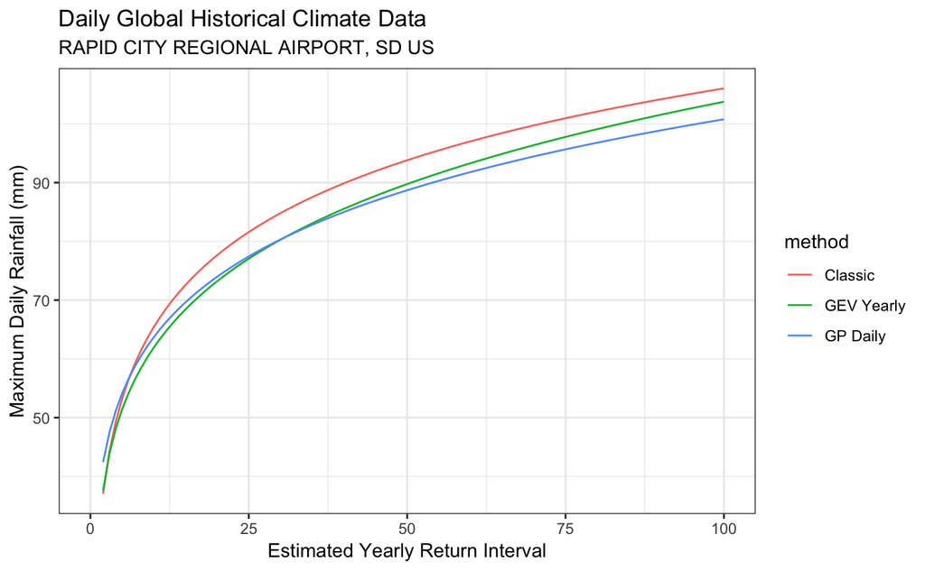

```r
#  plot rainfal vs return period -- with curve fit -- extended

ggplot(data = method_comparisons) +

  aes(x     = return_interval,
      y     = max_daily_prcp,
      color = method)  +

  theme_bw() +

  ggtitle(label    = "Daily Global Historical Climate Data",
          subtitle = ncdc_ids$name) +

  xlab(label = "Estimated Yearly Return Interval")  +

  ylab(label = "Maximum Daily Rainfall (mm)")  +



  xlim(0, 100) +

  geom_line()
```

```r
NA
NA
NA
```

So all three results diverge a longer return intervals but overall the displacement isn’t as bad as you’d maybe guess.